**Stack Overflow 2024 Developer Survey Analysis**

Welcome to the Stack Overflow 2024 Developer Survey Analysis. This presentation provides insights into the latest trends, technologies, and demographics of the developer community based on the responses from the annual Stack Overflow Developer Survey. We will explore various aspects such as the most popular programming languages, developer job satisfaction, and emerging technologies. Let's dive into the data and uncover the key findings from this year's survey

# Insights Covered

**Demographics:**  
Analysis of age, gender, and geographical distribution of developers.  
**Tools and technologies:**  
Overview of the most popular programming languages, frameworks, and tools used by developers.  
**Work preferences and habits:**  
Insights into developers' work environments, job satisfaction, and preferred work styles.

# Survey Scope

**Participants:**  
Over 65,000 participants from around the globe.  
**Regions:**  
Developers from 186 countries contributed to the survey.  
**Age Groups:**  
Passion transcends age, with participants ranging from under 18 to over 65 years old.

# Developer Demographics

In this section, we will explore the demographic characteristics of the survey respondents. This includes an analysis of their age distribution, gender, country of residence, and educational background. Understanding the demographics of the developer community helps us gain insights into the diversity and representation within the tech industry.

This chart illustrates the distribution of age groups within the developer community.

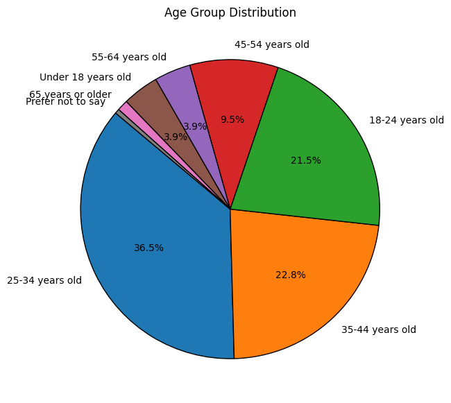

# Key Insights

- The majority of the developer community is composed of three age groups: 25-34, 35-44, and 18-24 years old. Together, these groups make up almost 81% of the developer community.
- The largest age group of developers falls within the 25-34 age range, followed by those aged 35-44.
- The smallest age groups are: under 18 years old, 55-64 years and 65 years or older.

Geographical Distribution

Here we will see the countries from which the survey respondents hail. Understanding the geographical distribution of developers provides insights into the global reach and diversity of the developer community.

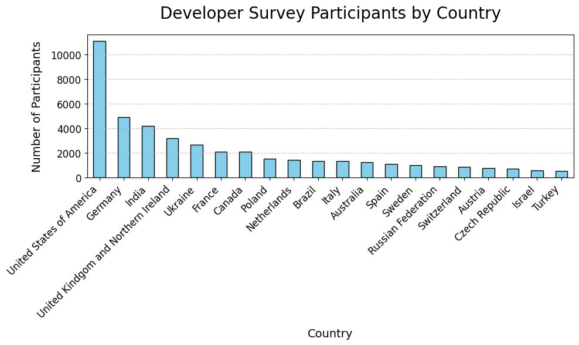